# TauREx 3.1 tutorial

Modified from [TauREx 3 tutorial](https://taurex3-public.readthedocs.io/en/latest/user/library/quickstart.html) under the BSD 3-Clause License

## Setup

Lets setup the notebook. If the plots arent interactive then run this part again

```python
import matplotlib.pyplot as plt

%matplotlib widget
from ipywidgets import *
import numpy as np
import sys
```

And lets disable logging

```python
import taurex.log

taurex.log.disableLogging()
```

## Loading cross-sections

We need to point TauREx3 to our cross-sections. This is handled by the caching classes. Once a cross-section is loaded it does not need to be loaded again. First lets import the classes:

```python
from taurex.cache import OpacityCache, CIACache
```

Now lets point the xsection and cia cachers to our files:

```python
OpacityCache().clear_cache()
OpacityCache().set_opacity_path("/ariel/data/SOFTWARE_DATA/xsec")
CIACache().set_cia_path("/ariel/data/SOFTWARE_DATA/cia")
```

TauREx3 is now ready to use them! For fun lets, try grabbing the H2O cross-section and plotting it. First tell the OpacityCache function to grab it.

```python
h2o_xsec = OpacityCache()["H2O"]
```

Now we can compute the cross-section for any pressure and temperature! Lets try 2000K and 10 Pa.

```python
h2o_xsec.opacity(2000, 10)
```

```
array([8.93277708e-26, 1.41929962e-25, 1.24608425e-25, ...,
       1.27362205e-33, 1.90153779e-33, 1.95851230e-33])
```

But why stop there? We can plot the temperature and pressure *interactively*

```
interactive(children=(FloatSlider(value=1500.0, description='temperature', max=2000.0, min=800.0, step=100.0),…
```

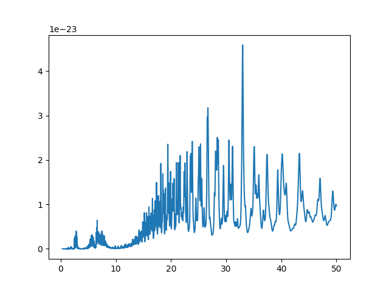

```python
xsec_fig = plt.figure()
xsec_ax = xsec_fig.add_subplot(1, 1, 1)


(xsec,) = xsec_ax.plot(10000 / h2o_xsec.wavenumberGrid, h2o_xsec.opacity(800, 1e0))


def update_cross(temperature=1500.0, pressure=6.7):
    xsec.set_ydata(h2o_xsec.opacity(temperature, 10**pressure))
    xsec_ax.relim()
    xsec_ax.autoscale_view()
    xsec_fig.canvas.draw()


interact(update_cross, temperature=(800.0, 2000.0, 100), pressure=(-1.0, 10.0, 1));
```

## Profiles

Now we need to setup our forward model. Lets create a temperature profile, we will use the Guillot profile but other brands are available:

```python
from taurex.temperature import Guillot2010

guillot = Guillot2010(T_irr=1200.0)
```

Now lets do the same for our planet:

```python
from taurex.planet import Planet

planet = Planet(planet_radius=1.0, planet_mass=1.0)
```

and the planets star:

```python
from taurex.stellar import BlackbodyStar

star = BlackbodyStar(temperature=5700.0, radius=1.0)
```

Now we need to define a chemistry profile, first lets setup the chemical model, we're going for the free-type model so we'll use *TaurexChemistry* which allows us to freely add any molecule:

```python
from taurex.chemistry import TaurexChemistry

chemistry = TaurexChemistry(fill_gases=["H2", "He"], ratio=0.172)
```

#### Adding molecules

Now we need to add some molecules. This is accomplished by the *addGas* function. We can create varius types of gas profiles for each molecule and add them in. Lets try the constant profile for H2O:

```python
from taurex.chemistry import ConstantGas

h2o = ConstantGas("H2O", mix_ratio=1.2e-4)
chemistry.addGas(h2o)
```

```
<taurex.data.profiles.chemistry.taurexchemistry.TaurexChemistry at 0x7f55c9c3ae00>
```

We can also create the gas on the spot as well:

```python
chemistry.addGas(ConstantGas("N2", mix_ratio=3.00739e-9))
```

```
<taurex.data.profiles.chemistry.taurexchemistry.TaurexChemistry at 0x7f55c9c3ae00>
```

And we're done for profiles! Like the cross-sections you can use them in isolation for your own evil deeds. Some require initialization with other profiles like pressure and altitude, you can find how to use them in the API documentation. An easy example are stars. Maybe you want to use the [**PHOENIX**](https://phoenix.ens-lyon.fr/Grids/BT-Settl/CIFIST2011_2015/FITS/) star library but don't want to bother coding the function to load and interpolate. Well you can just have *Taurex3* handle it for you!

```
WARNING: VerifyWarning: Invalid keyword for column 1: Column disp option (TDISPn) failed verification: Format E is not recognized. The invalid value will be ignored for the purpose of formatting the data in this column. [astropy.io.fits.column]
WARNING: VerifyWarning: Invalid keyword for column 2: Column disp option (TDISPn) failed verification: Format E is not recognized. The invalid value will be ignored for the purpose of formatting the data in this column. [astropy.io.fits.column]
```

```
interactive(children=(FloatSlider(value=5200.0, description='temperature', max=8000.0, min=800.0, step=400.0),…
```

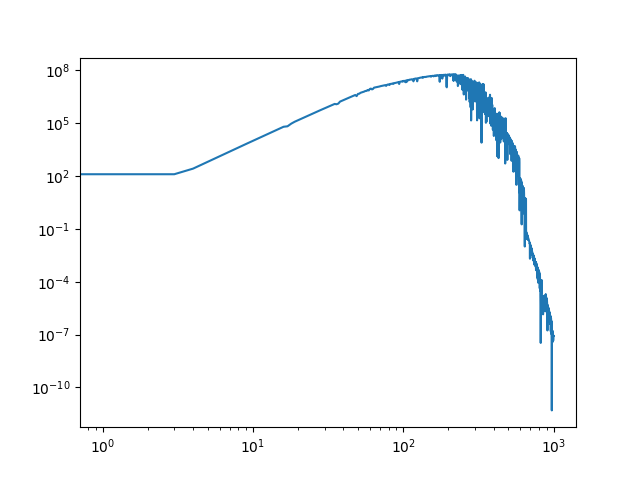

```python
from taurex.stellar import PhoenixStar

##

phoenix_path = "/ariel/data/SOFTWARE_DATA/phoenix_spectra"

anotherstar = PhoenixStar(phoenix_path=phoenix_path, temperature=5200.0)
star_fig = plt.figure()
star_ax = star_fig.add_subplot(1, 1, 1)

star_ax.set_xscale("log")
star_ax.set_yscale("log")

star_wngrid = np.linspace(0, 100000, 1000)

anotherstar.initialize(star_wngrid)

(pstar,) = star_ax.plot(anotherstar.spectralEmissionDensity)


def update_cross(temperature=5200.0):
    anotherstar.temperature = temperature
    anotherstar.initialize(star_wngrid)

    pstar.set_ydata(anotherstar.spectralEmissionDensity)
    star_ax.relim()
    star_ax.autoscale_view()
    star_fig.canvas.draw()


interact(update_cross, temperature=(800.0, 8000.0, 400));
```

After that quick detour lets carry on with our goal.

## Building the model

Now we can build our transmission model! Lets first create our transmission model and add our profiles to them:

```python
from taurex.model import TransmissionModel

tm = TransmissionModel(
    planet=planet,
    temperature_profile=guillot,
    chemistry=chemistry,
    star=star,
    atm_min_pressure=1e-0,
    atm_max_pressure=1e6,
    nlayers=30,
)
```

At this point our atmosphere has profiles but no physics! We can add this by including some contributions. Lets add in Absorption:

```python
from taurex.contributions import AbsorptionContribution

tm.add_contribution(AbsorptionContribution())
```

And some CIA for good measure:

```python
from taurex.contributions import CIAContribution

tm.add_contribution(CIAContribution(cia_pairs=["H2-H2", "H2-He"]))
```

And some rayleigh

```python
from taurex.contributions import RayleighContribution

tm.add_contribution(RayleighContribution())
```

Finally, putting it all together we **build** it to setup all the profiles

```python
tm.build()
```

Thats it! Our transmission model is complete! We can now run it:

```python
res = tm.model()
res
```

```
(array([  199.99326855,   200.00660143,   200.01993521, ...,
        33328.88933329, 33331.11125925, 33333.33333333]),
 array([0.01108351, 0.01109867, 0.0110766 , ..., 0.01095715, 0.01095717,
        0.01095718]),
 array([[0.00000000e+000, 0.00000000e+000, 0.00000000e+000, ...,
         6.08208944e-006, 6.08194445e-006, 6.08198450e-006],
        [0.00000000e+000, 0.00000000e+000, 0.00000000e+000, ...,
         3.31707865e-121, 3.06375263e-121, 2.82977206e-121],
        [0.00000000e+000, 0.00000000e+000, 0.00000000e+000, ...,
         2.03628005e-076, 1.93652007e-076, 1.84165169e-076],
        ...,
        [9.26538791e-001, 9.36616599e-001, 9.99452343e-001, ...,
         9.98284127e-001, 9.98283628e-001, 9.98283128e-001],
        [9.57295670e-001, 9.63275420e-001, 9.99781862e-001, ...,
         9.99046539e-001, 9.99046261e-001, 9.99045984e-001],
        [9.81321794e-001, 9.83965080e-001, 9.99907547e-001, ...,
         9.99587902e-001, 9.99587782e-001, 9.99587662e-001]]),
 None)
```

Nice! The output has four components:

- The wavenumber grid
- The *native* flux
- The optical depth
- Any extra information

Now lets plot it! Lets see the chemistry of the atmosphere:

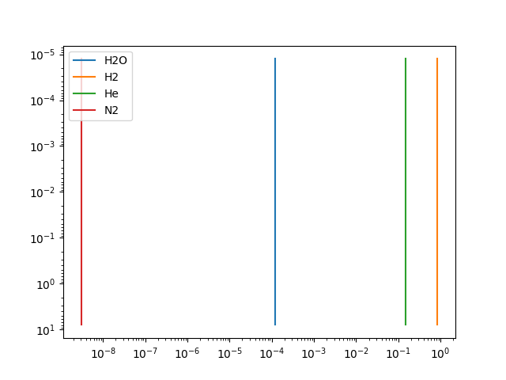

```python
plt.figure()

for x, gasname in enumerate(tm.chemistry.activeGases):
    plt.plot(
        tm.chemistry.activeGasMixProfile[x], tm.pressureProfile / 1e5, label=gasname
    )
for x, gasname in enumerate(tm.chemistry.inactiveGases):
    plt.plot(
        tm.chemistry.inactiveGasMixProfile[x], tm.pressureProfile / 1e5, label=gasname
    )
plt.gca().invert_yaxis()
plt.yscale("log")
plt.xscale("log")
plt.legend()
plt.show()
```

Not interesting, but our chemistry model is pretty simple!

And now lets plot the flux

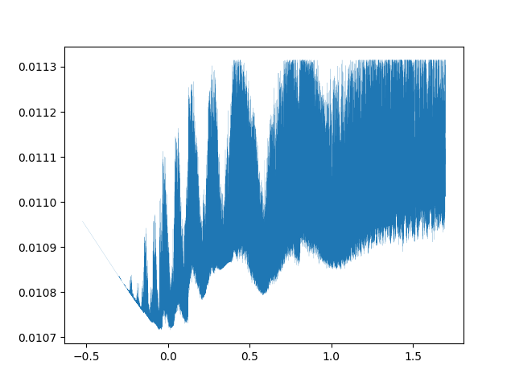

```python
native_grid, rprs, tau, _ = res

full_fig = plt.figure()
plt.plot(np.log10(10000 / native_grid), rprs, lw=0.1)
plt.show()
```

Coool! But lets try binning. We will use a simple but fast binner *SimpleBinner*.

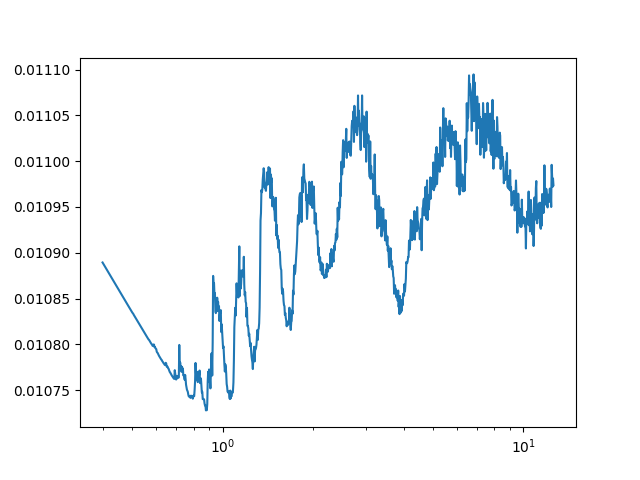

```python
from taurex.binning import SimpleBinner

binned_fig = plt.figure()


# Make a logarithmic grid
wngrid = np.sort(10000 / np.logspace(-0.4, 1.1, 1000))
bn = SimpleBinner(wngrid=wngrid)

bin_wn, bin_rprs, _, _ = bn.bin_model(tm.model(wngrid=wngrid))

plt.plot(10000 / bin_wn, bin_rprs)
plt.xscale("log")
plt.show()
```

Cool but the nice thing about TauREx is that you can alter any of the parameters and it will respond to it!

If any of the profiles are altered then model will respond to it. This means that parameters such as temperature and mix ratios and even contributions can be changed on the fly! Try this example out

```
interactive(children=(FloatSlider(value=1500.0, description='temperature', max=2000.0, min=800.0, step=100.0),…
```

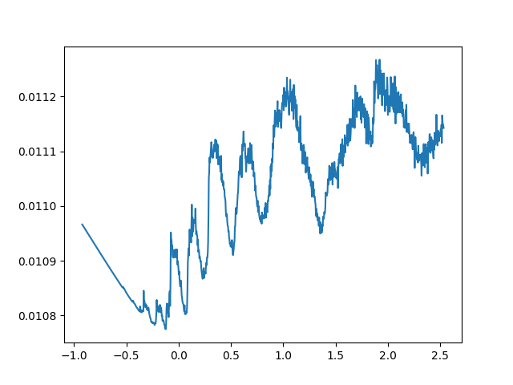

```python
wngrid = np.sort(10000 / np.logspace(-0.4, 1.1, 1000))
fig = plt.figure()
ax = fig.add_subplot(1, 1, 1)

(model,) = ax.plot(np.log(10000 / wngrid), bn.bin_model(tm.model(wngrid))[1])


def update_model(temperature=1500.0, h2o_mix=-4):
    guillot.equilTemperature = temperature
    tm["H2O"] = 10**h2o_mix
    model.set_ydata(bn.bin_model(tm.model(wngrid))[1])
    ax.relim()
    ax.autoscale_view()
    fig.canvas.draw()


interact(update_model, temperature=(800.0, 2000.0, 100), h2o_mix=(-12.0, -2.0, 1));
```

You can do some crazy things! If you reuse the same profiles on other models. You essentially couple them! That means you can have multiple model that all alter at the same time! We can see the equivalant Emission and Direct image spectrum like so:

```python
from taurex.model import EmissionModel, DirectImageModel

em = EmissionModel(
    planet=planet,
    temperature_profile=guillot,
    chemistry=chemistry,
    star=star,
    atm_min_pressure=1e-0,
    atm_max_pressure=1e6,
    nlayers=30,
)
di = DirectImageModel(
    planet=planet,
    temperature_profile=guillot,
    chemistry=chemistry,
    star=star,
    atm_min_pressure=1e-0,
    atm_max_pressure=1e6,
    nlayers=30,
)

em.add_contribution(AbsorptionContribution())
em.add_contribution(CIAContribution(cia_pairs=["H2-H2", "H2-He"]))
em.add_contribution(RayleighContribution())

di.add_contribution(AbsorptionContribution())
di.add_contribution(CIAContribution(cia_pairs=["H2-H2", "H2-He"]))
di.add_contribution(RayleighContribution())

em.build()
di.build()
```

```
interactive(children=(FloatSlider(value=1500.0, description='temperature', max=3000.0, min=800.0, step=100.0),…
```

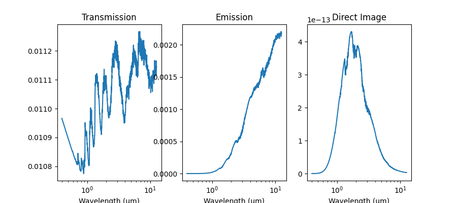

```python
wngrid = np.sort(10000 / np.logspace(-0.4, 1.1, 1000))

all_fig = plt.figure(figsize=(9, 4))
tm_ax = all_fig.add_subplot(1, 3, 1)
em_ax = all_fig.add_subplot(1, 3, 2)
di_ax = all_fig.add_subplot(1, 3, 3)
(model_tm,) = tm_ax.plot(10000 / wngrid, bn.bin_model(tm.model(wngrid))[1])
(model_em,) = em_ax.plot(10000 / wngrid, bn.bin_model(em.model(wngrid))[1])
(model_di,) = di_ax.plot(10000 / wngrid, bn.bin_model(di.model(wngrid))[1])
tm_ax.set_xscale("log")
em_ax.set_xscale("log")
di_ax.set_xscale("log")
tm_ax.set_title("Transmission")
em_ax.set_title("Emission")
di_ax.set_title("Direct Image")
tm_ax.set_xlabel("Wavelength (um)")
em_ax.set_xlabel("Wavelength (um)")
di_ax.set_xlabel("Wavelength (um)")


def update_model(temperature=1500.0, h2o_mix=-4):
    guillot.equilTemperature = temperature
    tm["H2O"] = 10**h2o_mix
    model_tm.set_ydata(bn.bin_model(tm.model(wngrid))[1])
    model_em.set_ydata(bn.bin_model(em.model(wngrid))[1])
    model_di.set_ydata(bn.bin_model(di.model(wngrid))[1])
    tm_ax.relim()
    tm_ax.autoscale_view()

    em_ax.relim()
    em_ax.autoscale_view()

    di_ax.relim()
    di_ax.autoscale_view()

    fig.canvas.draw()


interact(update_model, temperature=(800.0, 3000.0, 100), h2o_mix=(-7.0, -2.0, 1));
```

## Retrievals

To see what parameters available for retrievals we can list them like so:

```python
list(tm.fittingParameters.keys())
```

```
['planet_mass',
 'planet_radius',
 'planet_distance',
 'planet_sma',
 'atm_min_pressure',
 'atm_max_pressure',
 'T_irr',
 'kappa_irr',
 'kappa_v1',
 'kappa_v2',
 'alpha',
 'T_int_guillot',
 'H2O',
 'N2',
 'He_H2']
```

The thing is, this is *dynamic*, TauREx 3 figures out what can be fit based on whats in it. Lets throw an isothermal profile instead:

```python
from taurex.temperature import Isothermal

isothermal = Isothermal(T=1500.0)

tm = TransmissionModel(
    planet=planet,
    temperature_profile=isothermal,
    chemistry=chemistry,
    star=star,
    atm_min_pressure=1e-0,
    atm_max_pressure=1e6,
    nlayers=30,
)
tm.add_contribution(AbsorptionContribution())
tm.add_contribution(CIAContribution(cia_pairs=["H2-H2", "H2-He"]))
tm.add_contribution(RayleighContribution())
tm.build()
```

```python
tm.model()
```

```
(array([  199.99326855,   200.00660143,   200.01993521, ...,
        33328.88933329, 33331.11125925, 33333.33333333]),
 array([0.01118238, 0.01116944, 0.01113074, ..., 0.01101442, 0.01101444,
        0.01101446]),
 array([[0.00000000e+000, 0.00000000e+000, 0.00000000e+000, ...,
         4.27414757e-006, 4.27406870e-006, 4.27408048e-006],
        [0.00000000e+000, 0.00000000e+000, 0.00000000e+000, ...,
         2.19720154e-114, 2.03880061e-114, 1.89180721e-114],
        [0.00000000e+000, 0.00000000e+000, 0.00000000e+000, ...,
         4.31411147e-072, 4.11476113e-072, 3.92461345e-072],
        ...,
        [9.99757950e-001, 9.99837991e-001, 9.99833928e-001, ...,
         9.98502553e-001, 9.98502117e-001, 9.98501681e-001],
        [9.99875211e-001, 9.99917593e-001, 9.99913888e-001, ...,
         9.99167598e-001, 9.99167355e-001, 9.99167113e-001],
        [9.99948271e-001, 9.99966114e-001, 9.99964183e-001, ...,
         9.99640089e-001, 9.99639985e-001, 9.99639880e-001]]),
 None)
```

```python
list(tm.fittingParameters.keys())
```

```
['planet_mass',
 'planet_radius',
 'planet_distance',
 'planet_sma',
 'atm_min_pressure',
 'atm_max_pressure',
 'T',
 'H2O',
 'N2',
 'He_H2']
```

Here we lost the Guillot parameters like *T_irr* but gained the Isothermal parameter *T* We can also access them directly from the model using the brackets operator:

```python
tm["T"]
```

```
1500.0
```

And set them

```python
tm["H2O"] = 1.2e-4
```

We can create an observation to retrieve it later

```python
wlgrid = np.logspace(-0.4, 1.1, 50)[::-1]
wngrid = np.sort(10000 / wlgrid)

from taurex.util.util import compute_bin_edges

wn_edges, wn_widths = compute_bin_edges(wngrid)

from taurex.util.util import wnwidth_to_wlwidth

wl_widths = wnwidth_to_wlwidth(wngrid, wn_widths)

from taurex.binning import FluxBinner

bn = FluxBinner(wngrid=wngrid, wngrid_width=wn_widths)
```

```python
bin_wn, bin_rprs, _, _ = bn.bin_model(tm.model(wngrid=wngrid))

noise = 50e-6 * np.ones_like(bin_rprs)

observation = np.c_[wlgrid, bin_rprs, noise, wl_widths]

np.savetxt("observation.dat", observation)
```

Lets use *ObservedSpectrum* to load a text one:

```python
from taurex.data.spectrum.observed import ObservedSpectrum

obs = ObservedSpectrum("observation.dat")
```

Convieniently we have a way of binning our native spectrum down to the observation by calling its *create_binner* method:

```python
obin = obs.create_binner()
```

And we can now plot

But first, let's pretend that we do not know the temperature of the atmosphere and try out some values, like the below

```python
tm["T"] = 1445.0
```

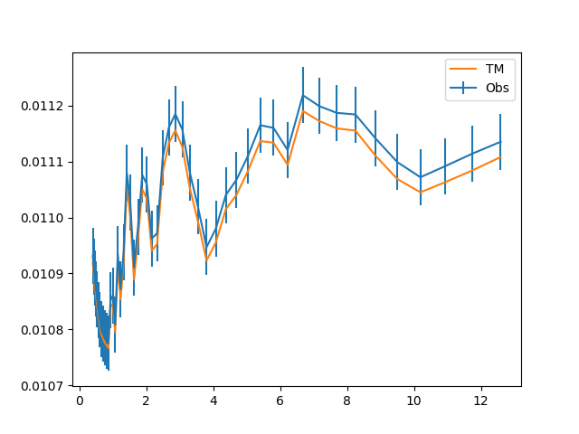

```python
plt.figure()
plt.errorbar(obs.wavelengthGrid, obs.spectrum, obs.errorBar, label="Obs")
plt.plot(
    obs.wavelengthGrid, obin.bin_model(tm.model(obs.wavenumberGrid))[1], label="TM"
)
plt.legend()
plt.show()
```

Ew not good! Lets try a retrieval! We have many optimizers to choose so lets create one using the inbuilt optimizer based on [nestle](http://kylebarbary.com/nestle/)

```python
from taurex.optimizer.nestle import NestleOptimizer

opt = NestleOptimizer(num_live_points=50)
```

We need to tell it about our forward model and observation:

```python
opt.set_model(tm)
opt.set_observed(obs)
```

Now lets enable which parameters to fit and their prior boundaries:

```python
opt.enable_fit("planet_radius")
opt.set_boundary("planet_radius", [0.8, 2.1])

opt.enable_fit("T")
opt.set_boundary("T", [1000, 2000])

opt.enable_fit("H2O")
opt.set_mode("H2O", "log")
opt.set_boundary("H2O", [1e-9, 1e-1])
```

Now lets fit!!!!

```python
solution = opt.fit()
taurex.log.disableLogging()
```

```
it=   612 logz=437.381337821961
```

[output not shown]

```
niter: 613
ncall: 1544
nsamples: 663
logz: 437.749 +/-  0.447
h:  9.978
```

[output not shown]

# Let's plot

```python
# for sol, optimized_map, optimized_value, values in opt.get_solution():
#     opt.update_model(optimized_map)
#     plt.figure()
#     plt.errorbar(obs.wavelengthGrid, obs.spectrum, obs.errorBar, label="Obs")
#     plt.plot(
#         obs.wavelengthGrid, obin.bin_model(tm.model(obs.wavenumberGrid))[1], label="TM"
#     )
#     plt.legend()
#     plt.show()
```

```python
modelAxis = {
    "TransmissionModel": "$(R_p/R_*)^2$",
    "TransmissionCudaModel": "$(R_p/R_*)^2$",
    # "EmissionModel": "$F_p/F_*$",
    # "EmissionCudaModel": "$F_p/F_*$",
    # "DirectImageModel": "$F_p$",
    # "DirectImageCudaModel": "$F_p$",
}
```

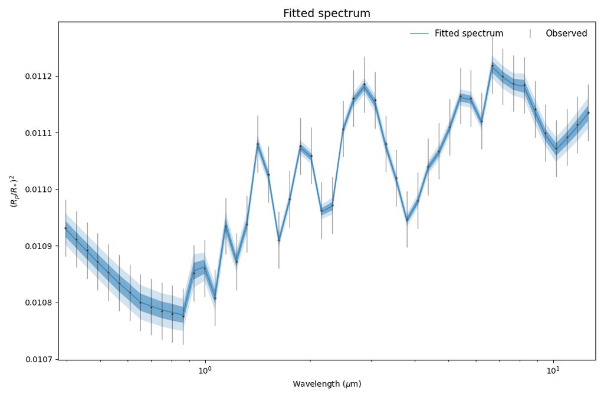

```python
fig = plt.figure(figsize=(10.6, 7.0))

obs_spectrum = opt._observed.spectrum
error = opt._observed.errorBar
wlgrid = opt._observed.wavelengthGrid

plt.errorbar(
    wlgrid,
    obs_spectrum,
    error,
    lw=1,
    color="black",
    alpha=0.4,
    ls="none",
    zorder=0,
    label="Observed",
)

for solution_idx, solution_val in solution.items():
    binned_grid = solution_val["Spectra"]["binned_wlgrid"][...]
    native_grid = solution_val["Spectra"]["native_wngrid"][...]

    plt.scatter(
        wlgrid,
        obs_spectrum,
        marker="d",
        zorder=1,
        **{"s": 10, "edgecolors": "grey", "color": "black"}
    )

    binned_spectrum = solution_val["Spectra"]["binned_spectrum"][...]
    binned_error = solution_val["Spectra"]["binned_std"][...]

    color = "C0"
    label = "Fitted spectrum"
    plt.plot(wlgrid, binned_spectrum, label=label, color=color, alpha=0.6)
    if binned_error is not None:
        # 1 sigma
        plt.fill_between(
            wlgrid,
            binned_spectrum - binned_error,
            binned_spectrum + binned_error,
            alpha=0.5,
            zorder=-2,
            color=color,
            edgecolor="none",
        )

        # 2 sigma
        plt.fill_between(
            wlgrid,
            binned_spectrum - 2 * binned_error,
            binned_spectrum + 2 * binned_error,
            alpha=0.2,
            zorder=-3,
            color=color,
            edgecolor="none",
        )


plt.xlim(np.min(wlgrid) - 0.05 * np.min(wlgrid), np.max(wlgrid) + 0.05 * np.max(wlgrid))
plt.xlabel(r"Wavelength ($\mu$m)")
plt.ylabel(modelAxis[tm.__class__.__name__])

if np.max(wlgrid) - np.min(wlgrid) > 5:
    plt.xscale("log")
    plt.tick_params(axis="x", which="minor")
plt.legend(loc="best", ncol=2, frameon=False, prop={"size": 11})

plt.title("Fitted spectrum", fontsize=14)
plt.tight_layout()
plt.show()
```

Nice!

```python
def get_derived_parameters(solution):
    if "derived_params" in solution:
        return [c for k, c in solution["derived_params"].items()]
    else:
        return [solution["fit_params"]["mu_derived"]]
```

```python
from taurex.util.util import quantile_corner


def compute_ranges(multivariate, weights, sigma=5):
    ranges = []
    for i in range(multivariate.shape[1]):
        trace = multivariate[:, i]
        q_16, q_50, q_84 = quantile_corner(trace, [0.16, 0.5, 0.84], weights=weights)
        sigma_m = q_50 - q_16
        sigma_p = q_84 - q_50
        ranges.append((q_50 - sigma * sigma_m, q_50 + sigma * sigma_p))
    return ranges
```

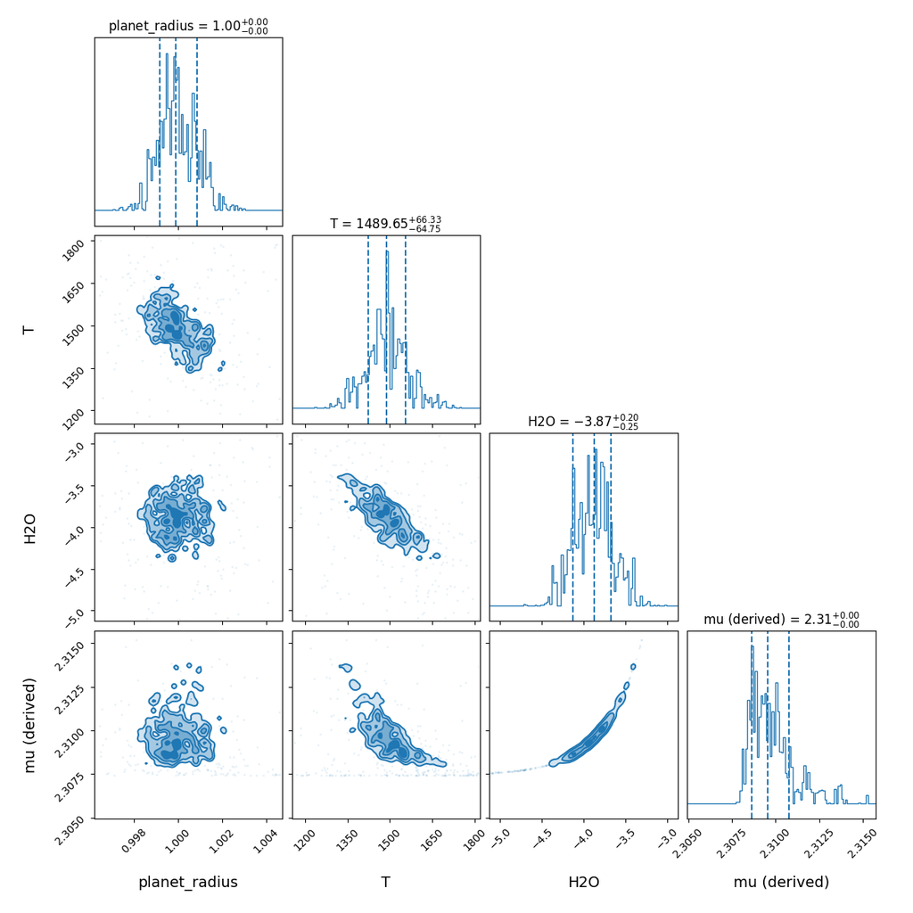

```python
import corner

fittingNames = [param[0] for param in opt.fitting_parameters]

figs = []
fig = plt.figure(figsize=(12, 12))

for solution_idx, solution_val in solution.items():
    tracedata = solution_val["tracedata"]
    weights = solution_val["weights"]
    indices = np.array([fittingNames.index(x) for x in fittingNames])

    mu_derived = get_derived_parameters(solution_val)
    _tracedata = np.column_stack((tracedata, mu_derived[0]["trace"]))
    fittingNames.append("mu (derived)")

    figure_past = fig

    plt.rc("xtick", labelsize=10)  # size of individual labels
    plt.rc("ytick", labelsize=10)
    plt.rc("axes.formatter", limits=(-4, 5))  # scientific notation..

    ranges = compute_ranges(_tracedata, weights)

    fig = corner.corner(
        _tracedata,
        weights=weights,
        range=ranges,
        labels=fittingNames,
        label_kwargs=dict(fontsize=14),
        smooth=1.5,
        scale_hist=True,
        quantiles=[0.16, 0.5, 0.84],
        show_titles=True,
        title_kwargs=dict(fontsize=12),
        # truths=truths,
        truth_color="black",
        ret=True,
        fill_contours=True,
        color=color,
        top_ticks=False,
        bins=100,
        fig=figure_past,
    )
    # fig.gca().annotate(
    #     "Posterior %s" % (solution_idx),
    #     xy=(0.5, 0.96),
    #     xycoords="figure fraction",
    #     xytext=(0, -5),
    #     textcoords="offset points",
    #     ha="center",
    #     va="top",
    #     fontsize=20,
    # )
plt.show()
```